# Convolutional Neural Networks

## Project: Write an Algorithm for Landmark Classification

### A simple app

In this notebook we build a very simple app that uses our exported model.

[figure not shown]

> Note how we are not importing anything from our source code (we do not use any module from the `src` directory). This is because the exported model, differently from the model weights, is a standalone serialization of our model and therefore it does not need anything else. You can ship that file to anybody, and as long as they can import `torch`, they will be able to use your model. This is very important for releasing pytorch models to production.

### Test your app

Go to a search engine for images (like Google Images) and search for images of some of the landmarks, like the Eiffel Tower, the Golden Gate Bridge, Machu Picchu and so on. Save a few examples locally, then upload them to your app to see how your model behaves!

The app will show the top 5 classes that the model think are most relevant for the picture you have uploaded

```python
from google.colab import drive
drive.mount('/content/gdrive')


%cd gdrive/My\ Drive/Colab_Notebooks/Master_AI_journey/Deep_Learning_Nano/CNN/CNN_project/
```

```
/content/gdrive/My Drive/Colab_Notebooks/Master_AI_journey/Deep_Learning_Nano/CNN/CNN_project
```

External Image Predictions

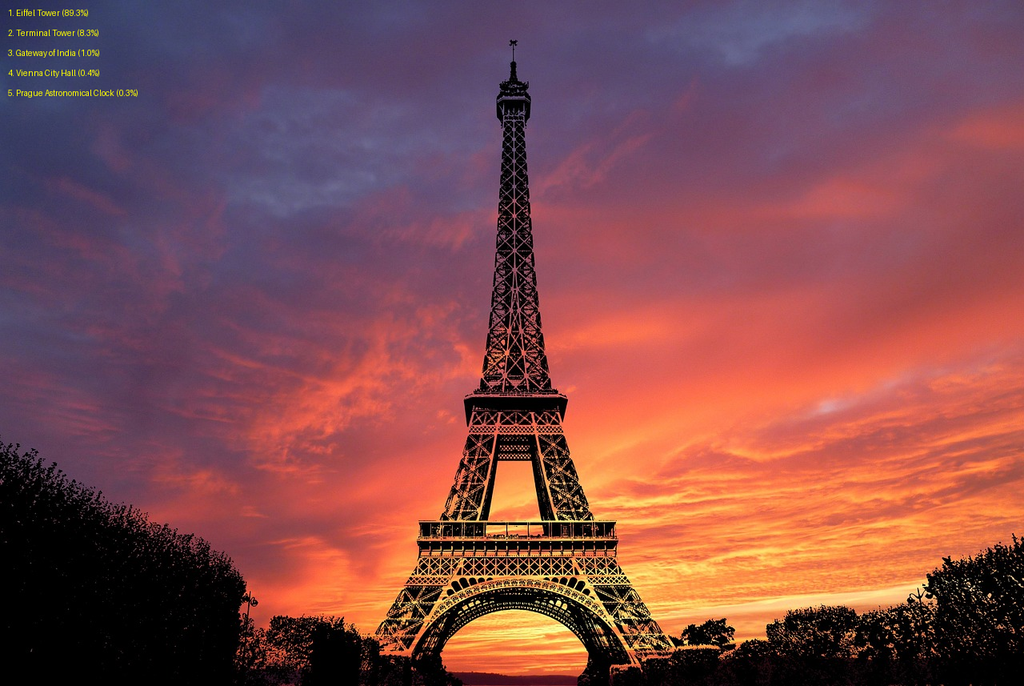

1. Eiffel Tower (89.3%)

2. Terminal Tower (8.3%)

3. Gateway of India (1.0%)

4. Vienna City Hall (0.4%)

5. Prague Astronomical Clock (0.3%)

```python
from PIL import Image, ImageDraw, ImageFont
import torchvision.transforms as T
import torch
import numpy as np
from IPython.display import display, HTML

# External image (not in training/test)
external_image_path = "external_image_3.jpg"

# Load your exported model (transfer learning or scratch)
learn_inf = torch.jit.load("checkpoints/transfer_exported.pt")


# -------------------------------
# 1) Load image and get predictions
# -------------------------------
img = Image.open(external_image_path).convert("RGB")
timg = T.ToTensor()(img).unsqueeze_(0)
softmax = learn_inf(timg).data.cpu().numpy().squeeze()
idxs = np.argsort(softmax)[::-1]

# -------------------------------
# 2) Get top-5 predictions
# -------------------------------
top_preds = []
for i in range(5):
    p = softmax[idxs[i]] * 100  # convert to %
    name = learn_inf.class_names[idxs[i]].split(".", 1)[-1].replace("_", " ")
    top_preds.append((name, p))

# -------------------------------
# 3) Draw predictions on image
# -------------------------------
draw = ImageDraw.Draw(img)
try:
    font = ImageFont.truetype("arial.ttf", 20)
except:
    font = ImageFont.load_default()

for i, (name, prob) in enumerate(top_preds):
    draw.text((10, 10 + i*25), f"{i+1}. {name} ({prob:.1f}%)", fill="yellow", font=font)

# -------------------------------
# 4) Display in notebook
# -------------------------------
display(HTML("<h3>External Image Predictions</h3>"))
display(img)

# Also display as text
html_preds = "<ol>"
for name, prob in top_preds:
    html_preds += f"<li>{name} ({prob:.1f}%)</li>"
html_preds += "</ol>"
display(HTML(html_preds))
```

# Create your submission archive

Now that you are done with your project, please run the following cell. It will generate a file containing all the code you have written, as well as the notebooks. Please submit that file to complete your project

```python
!python src/create_submit_pkg.py
```